# ETC5521 Diving Deeper into Data Exploration: Assignment 2

Author

Caoyu Shao

Published

September 1, 2025

## Question 1

Time stamps and sample inclusion. Fourteen percent of records lack date–time onsets and cannot be assigned to specific times, making them unsuitable for time-series analysis. Unless noted otherwise, analyses are restricted to the remaining 86% of observations with valid timestamps; the 14% with missing time information are excluded.

Table 1: Variable summary (interactive)

| Variable | Type | N_missing | Example_values |
| --- | --- | --- | --- |
| Site ID | numeric | 0 | 229108,229142,229143 |
| Name | character | 0 | YARRA DS MCMAHONS,YARRA @ TEMPLESTOWE,YARRA @ CHANDLER HWY |
| Datetime | POSIXct/POSIXt | 2271 | 1962-06-15,1962-06-15 23:59:59,1962-06-16 23:59:59 |
| Data Type | character | 0 | Quantity,Quality |
| Parameter ID | numeric | 0 | 141.5,2054,215 |
| Parameter | character | 0 | Streamflow (mean daily),Colour (True Filtered) (PCU),Dissolved Oxygen (DO) (field) |
| Value | numeric | 0 | 80,84,95 |
| Unit of Measurement | character | 0 | ML/day,Pt-Co,ppm |
| Quality | numeric | 0 | 1,255,151 |
| Resolution | character | 0 | Raw Data |

From the tibble above, we can get that there are ten variables from the dataset. They are Site ID, Name, Datetime, Data Type, Parameter ID, Parameter , Value, Unit of Measurement, Quality, Resolution.

Site ID means the ID of site and its value format is numeric.

Name means the name of the site. Its format is character.

Datetime means the observation time, which format is c(“POSIXct”, “POSIXt”). In this column, there are 2271 value missing, accounting for 0.14 of all the observations.

Data type is description of the value, it could be quanlity or quantity and its format is character. The quantity value is the observation of Streamflow(mean daily) and the quality value are some water quality variables like pH, nitrogen. And according to the assignment instructions, we need to focus on the quality parameters.

Parameter ID is the ID of the parameter, and each parameter has one ID. Parameter is what we have recorded. Like stream flow, colour and dissolved oxygen.

The value is the corresponding value to the parameters. Like if the parameter is streamflow and the value is 202, it means that the streamvalue is 202.

The Unit of measurement is the unit of value and its format is character. Quality is the numeric format and it means that the quality of the parameter.

Resolution is a kind of data processing level.Here it means the data is raw and has not been processed ever.

From SW Metadata.csv, we could know that one site ID correspond to one site. Besides, every site has one site ID. So what we need to do firstly is to mutate a column which indicates the site name corresponding to each ID and then to cluster the observations sharing the same site ID and then calculate the number of it.

Table 2: Observation counts by site (interactive)

| Site ID | Name | n_obs |
| --- | --- | --- |
| 229108 | YARRA DS MCMAHONS | 6573 |
| 229143 | YARRA @ CHANDLER HWY | 3509 |
| 229200 | YARRA @ WARRANDYTE | 2271 |
| 229147 | YARRA @ YERING GORGE | 2083 |
| 229142 | YARRA @ TEMPLESTOWE | 1947 |

Table 3: Observation counts by parameter (interactive)

| Parameter | n_obs | Share |
| --- | --- | --- |
| Streamflow (mean daily) | 14764 | 0.9011780504181164 |
| Salinity as EC@25 | 225 | 0.01373374839772935 |
| Water Temperature | 225 | 0.01373374839772935 |
| pH | 225 | 0.01373374839772935 |
| Turbidity | 221 | 0.01348959287065861 |
| Nitrogen as Nitrite (NO3) | 53 | 0.003235060733687359 |
| Nitrogen as Total | 53 | 0.003235060733687359 |
| Phosphorus as TRP | 53 | 0.003235060733687359 |
| Total Arsenic | 53 | 0.003235060733687359 |
| Total Cadmium | 53 | 0.003235060733687359 |

[output cut: 13 more lines]

The water temperature has 225 observations.

PH has 225 observations. When looking into the dataset, we could see two outliner with its pH value 0, it is unreasonable because the river water can hardly reach the pH value 0. I think it may be a mistake here. For example, in practical situations, the missing value usually is recorded as zero. So we decide to remove the two points.

Turbidity has 221 observations. I find that the turbility value equals to zero sometimes. It’s unreasonable to get 0 in turbility especially for an open water.So i remove them from clean data.

And all the parameters above have observations from 1990-1994 and 2020-2025.

Nitrogen as Total, Nitrogen as Total Kjeldahl (TKN),Nitrogen as Nitrate(NOx), these three parameters are very special. Nitrogen as Nitrate(NOx) only has observations from 1990s, while ther Nitrogen as Total has observations only from 2020s and TKN has only observations from 1990s. After searching for some information about it, we got that Nitrogen as total = TKN + NOx. So after cleaning it, it could work as an important parameters for measuring water eutrophication.

Nitrogen as Nitrite(NO3) has only observations from 2020 without the data from 1990-1994, so it is insufficient to answer the question.

Nitrogen as Ammonia (Total) and Nitrogen as Nitrate (NO2), these two parameters have only two observations on 2020-04-02 and 2020-06-05. They are not sufficient to answer the question.Beside, i find the Nitrogen as Ammonia(Total) value are all zero.I think the reason is that the value was below the detection value standard. I decide not to remove it.

Phosphorus as TRP, Phosphrous(total), Phosphorous as FRP,these three parameters are also other important parameters to measure water eutrophication. But unluckily, Phosphrous(total) has observations from 1990s , but in 2020 there is only one observation. Phosphorus(FRP) has only observations from 1990s. Phosphorus(TRP) has only observations from 2020s. And after searching for the information online, i can’t find the relationship between these three parameters. So they are not sufficient. And they have zero values in TRP, I think the reason for that is the value was below the detection value standard. I decide not to remove it.

Total Arsenic, Total cadmium, Total Chromium, Total Copper, Total Nickle, Total Zinc, these parameters all have 53 observations. They have the data in 2020s but not in 1990s so they are not sufficient to answer the question. Total cadmium is zero in observations, and cadmium is a harmful chemical mineral for humans. So this zero should be the value is below the detection standard. So i reserve it in my clean data.

Colour has data from 1990s, but in 2020s, there is no data about it. So it is not sufficient.

Total Suspended Solids have 32 observations. It only contains the information in 1990s. It is not sufficient to answer the question.

## Question 2

In this section, we will focus on exploring pH value, EC@25 value and nitrogen value. These three paramters are very important for us to measure the quality of water. pH value reflects the acidity and alkalinity of water. Generally speaking, weak alkalinity is more suitable for biological survival. EC@25 reflects the number of conductive ions in water. The larger the value, the higher the mineralization. Nitrogen reflects the degree of eutrophication of the water body, because nitrogen is an essential element for plant growth. If the concentration of nitrogen in the water increases, it will stimulate the growth of some algae in the water, squeezing out the oxygen space for the original ecology.

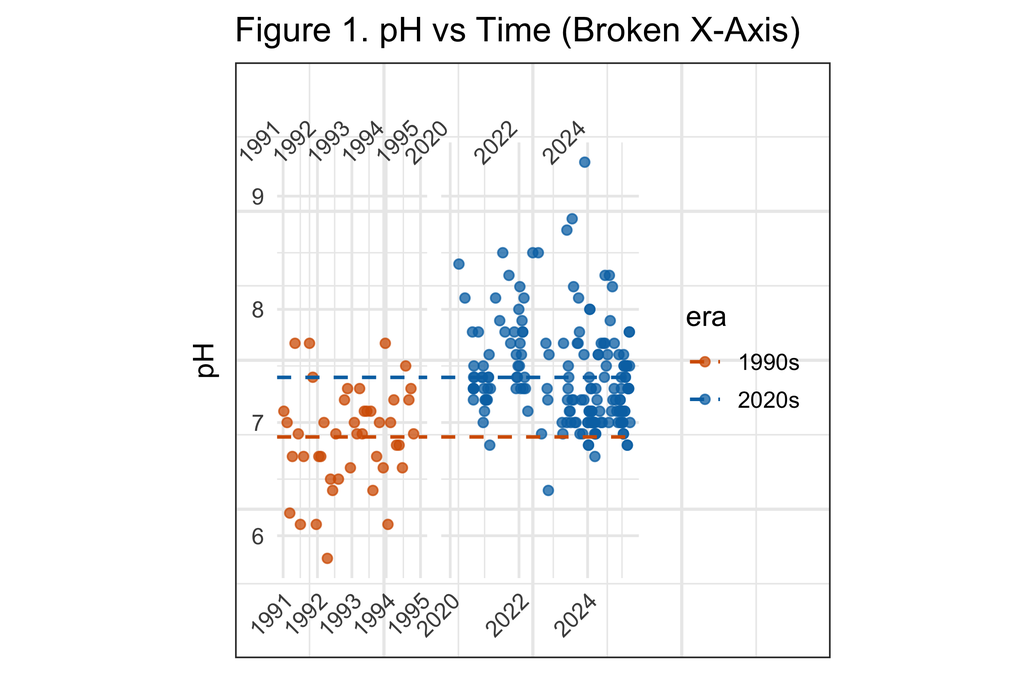

From Figure 1, We can get that the mean value of the pH of water in 2020s is a little higher than that in 1990s.

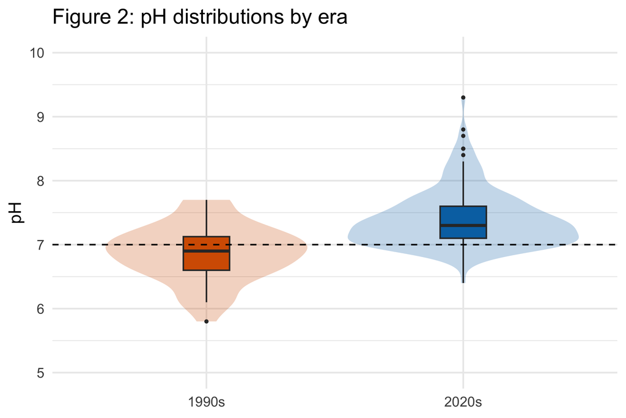

From Figure 2, we could find that the median, 75% percentile, 25% percentile value of pH from 2020s are all higher than those in 1990s. The majority of pH in 1990s was approximately 7, and the majority of pH in 2020s was a little above 7.

| era | n | mean | sd | var | median | min | max | ci_lo | ci_hi |
| --- | --- | --- | --- | --- | --- | --- | --- | --- | --- |
| 1990s | 44 | 6.87 | 0.44 | 0.2 | 6.9 | 5.8 | 7.7 | 6.74 | 7.01 |
| 2020s | 179 | 7.4 | 0.44 | 0.2 | 7.3 | 6.4 | 9.3 | 7.33 | 7.46 |

From the tibble above, we could know that the pH of the water in 1990-1994 is lower than that in 2020-2025. However, the variances of the observations from these two era are approximately the same. And the 95% confident interval in 1990s is [6.74,7.00], and the value in 2020s is [7.33,7,46]. According to EPA Victoria, fresh water at both time points meets the requirements. Besides, the pH has improved a little.

Salinity as EC@ 25 is a parameter which could reflect the water quality. And EC means the electrical conductivity reflecting the total amount and intensity of conductive dissolved ions in water. The more ions andthe higher the concentration , the greater the EC. Due to the Electrical conductivity was affected by temperature, and this parameter has a standardized process, it will convert the value to that in 25 degree.

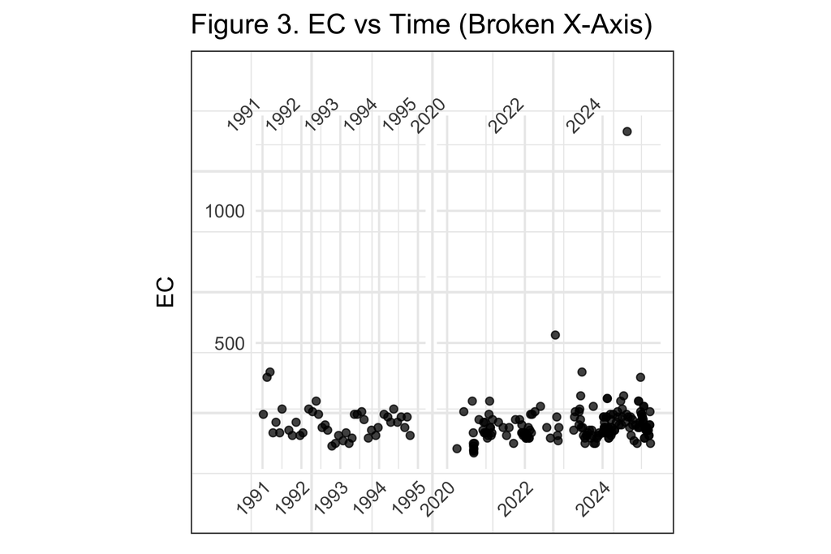

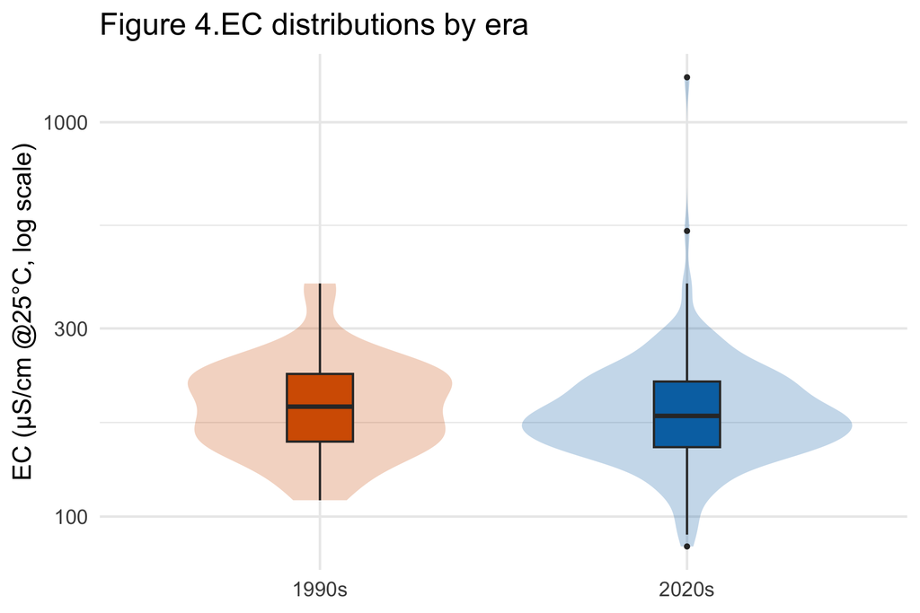

From Figure 4.we could find that the median value, 25%, 75% percentile value from 2020s are all lower than those in 1990s.

| era | n | mean | sd | var | median | min | max | ci_lo | ci_hi |
| --- | --- | --- | --- | --- | --- | --- | --- | --- | --- |
| 1990s | 43 | 197.21 | 58.45 | 3415.84 | 190 | 110 | 390 | 179.22 | 215.2 |
| 2020s | 179 | 193.46 | 99.52 | 9904.05 | 180 | 84 | 1300 | 178.78 | 208.14 |

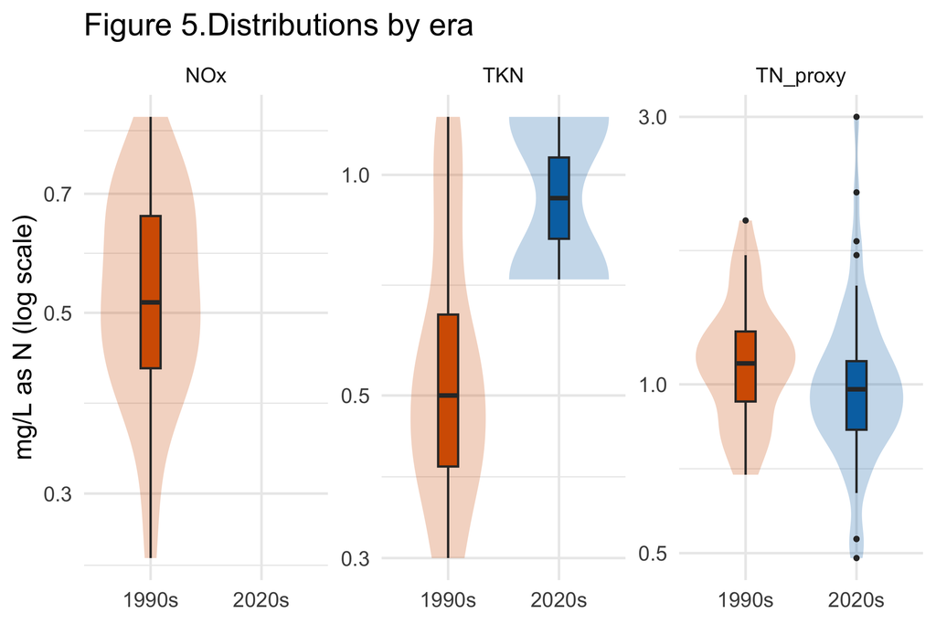

From Figure 5,because the number of TKN observations is only two in 2020s. So i focus on the total nitrogen proxy. It indicates that 25% percentile , 75% percentile and median value decreased from 1990s. It means the improved nutrient richness of water bodies.

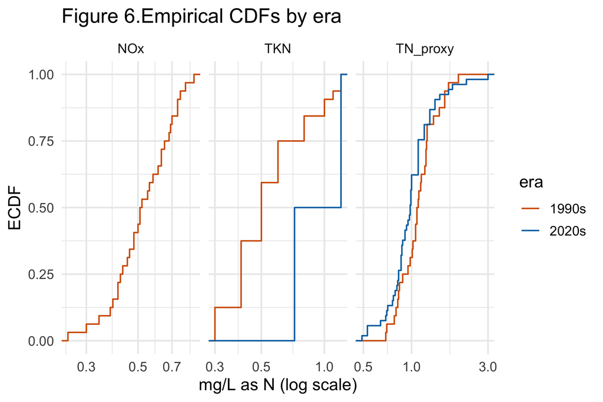

From figure 6, we could see that most of the time the blue line is on the left of the orange line. So we could know that in 2020s we got some extra large value, but from the perspective of most of the observations, the value has been improved.

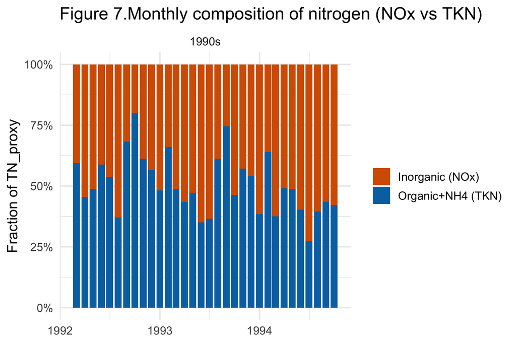

From Figure 7, we could get the inner proportion of the Nitrogen proxys in 1990s, it indicates that the TKN is decreasing and inorganic makes up more from 1990 to 1994.

| parameter | n | mean | sd | var | median | min | max | ci_lo | ci_hi |
| --- | --- | --- | --- | --- | --- | --- | --- | --- | --- |
| Overall (NOx + TKN) | 34 | 1.12 | 0.3 | 0.09 | 1.09 | 0.69 | 1.96 | 1.02 | 1.23 |
| Nitrogen as NOx | 32 | 0.54 | 0.15 | 0.02 | 0.52 | 0.25 | 0.87 | 0.49 | 0.6 |
| Nitrogen as Total | 53 | 1.05 | 0.42 | 0.17 | 0.98 | 0.49 | 3 | 0.94 | 1.17 |
| Nitrogen as Total Kjeldahl (TKN) | 34 | 0.61 | 0.28 | 0.08 | 0.5 | 0.3 | 1.2 | 0.51 | 0.71 |

Line 1 is the nitrogen value in 1990s, we use sum of NOx and tkn to estimate the total nitrogen value , we get the mean value is 1.12, and 95% confidence interval is [1.02,1.23]. And in 2020s, line 3 has reflected the nitrogen value well. We could see that the mean value is 1.05, a little lower than 1990s, and the 95% confidece interval is [0.94,1.17]. Now, we could conclude that from the perspective of nitrogen, the nutrient richness of water bodies has improved from the 1990s to the 2020s.

From the aspects of pH value, ED@ 25 and Nitrogen, we could find that the water quality has improved from 1990s to 2020s.

## Question 3

The null hypothesis from Figure 1 is that the mean of the pH value in the sample in 1990s is the same as that in 2020s. According to the code from Figure1, we could know that this is a scatterpoint plot to indicate the mean pH value. What we do is to permute the era label of the observations and then calculate the mean of value. If the null hypothesis is acccepted, then mean should be the same. And i will insert Figure 1 to all the lineup plots.

[figure not shown]

The null hypothesis is that pH value in 2020s has the same distribution as that of 1990s. This null hypothesis corresponds to Figure 2. According to the code from Figure2 , we could know that this is a violin plot which could illustrate the pH value distribution in 1990s and 2020s. Since we have the null hypothesis, then we could assume that they share the same distribution. So I permute the era labels within 1990s and 2020s. If the null hypothesis is accepted, then all the plots should have the same plot. And we insert our real plot in the lineup plots.

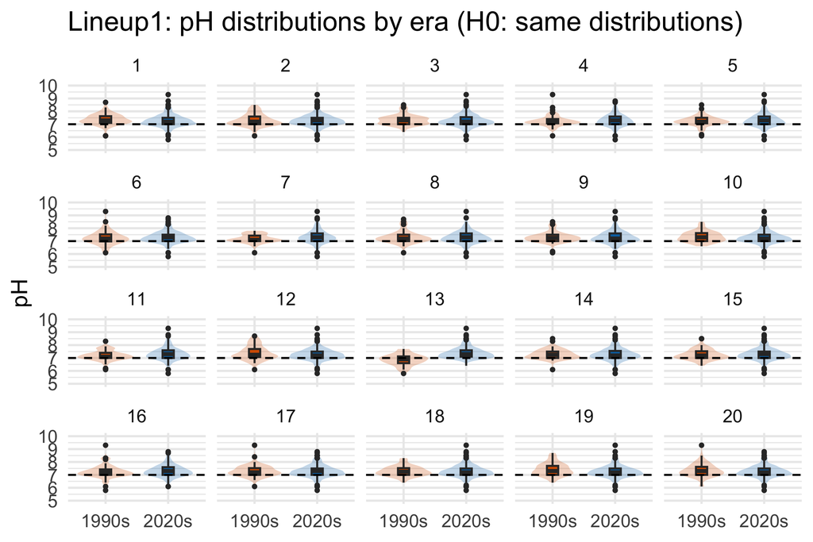

The null hypothesis is that the EC value distribution in 1990s is the same as that in 2020s. This null hypothesis corresponds to Figure 4. According to the code from Figure4 , we could know that this is a violin plot which could illustrate the EC@ 25 value distribution in 1990s and 2020s. Since we have the null hypothesis, then we could assume that they share the same distribution. So I permute the era labels within 1990s and 2020s. If the null hypothesis is accepted, then all the plots should have the same plot. And we insert our real plot in the lineup plots.

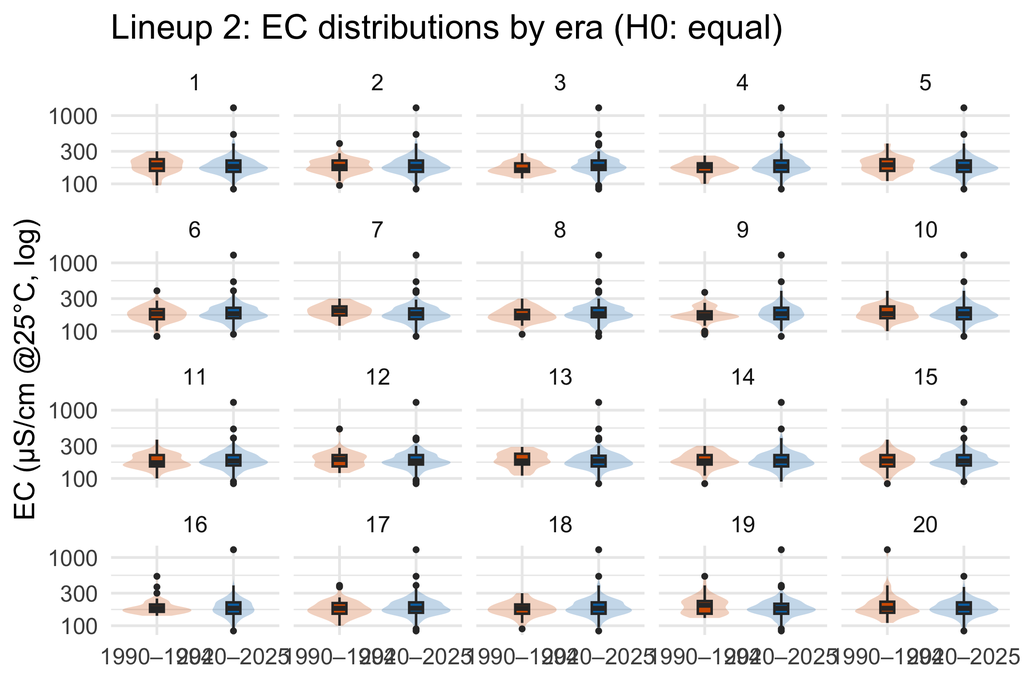

## Resources

The materials used for this report are:

Wickham H, Averick M, Bryan J, Chang W, McGowan LD, François R, Grolemund G, Hayes A, Henry L, Hester J, Kuhn M, Pedersen TL, Miller E, Bache SM, Müller K, Ooms J, Robinson D, Seidel DP, Spinu V, Takahashi K, Vaughan D, Wilke C, Woo K, Yutani H (2019). “Welcome to the tidyverse.” *Journal of Open Source Software*, *4*(43), 1686. [doi:10.21105/joss.01686](https://doi.org/10.21105/joss.01686).

Wickham H (2023). *conflicted: An Alternative Conflict Resolution Strategy*. R package version 1.2.0, https://CRAN.R-project.org/package=conflicted.

Wickham H, Bryan J (2025). *readxl: Read Excel Files*. R package version 1.4.5, https://CRAN.R-project.org/package=readxl.

Müller K, Wickham H (2023). *tibble: Simple Data Frames*. R package version 3.2.1, https://CRAN.R-project.org/package=tibble.

Müller K (2020). *here: A Simpler Way to Find Your Files*. R package version 1.0.1, https://CRAN.R-project.org/package=here.

Wickham H, Hester J, Bryan J (2024). *readr: Read Rectangular Text Data*. R package version 2.1.5, https://CRAN.R-project.org/package=readr.

Firke S (2024). *janitor: Simple Tools for Examining and Cleaning Dirty Data*. R package version 2.2.1, https://CRAN.R-project.org/package=janitor.

Wickham H, François R, Henry L, Müller K, Vaughan D (2023). *dplyr: A Grammar of Data Manipulation*. R package version 1.1.4, https://CRAN.R-project.org/package=dplyr.

Garrett Grolemund, Hadley Wickham (2011). Dates and Times Made Easy with lubridate. Journal of Statistical Software, 40(3), 1-25. URL https://www.jstatsoft.org/v40/i03/.

Wickham H, Vaughan D, Girlich M (2024). *tidyr: Tidy Messy Data*. R package version 1.3.1, https://CRAN.R-project.org/package=tidyr.

S Xu, M Chen, T Feng, L Zhan, L Zhou, G Yu. Use ggbreak to effectively utilize plotting space to deal with large datasets and outliers. Frontiers in Genetics. 2021, 12:774846. doi: 10.3389/fgene.2021.774846

H. Wickham. ggplot2: Elegant Graphics for Data Analysis. Springer-Verlag New York, 2016.

Wickham H (2023). *stringr: Simple, Consistent Wrappers for Common String Operations*. R package version 1.5.1, https://CRAN.R-project.org/package=stringr.

Wickham H, Pedersen T, Seidel D (2023). *scales: Scale Functions for Visualization*. R package version 1.3.0, https://CRAN.R-project.org/package=scales.

Buja A, Cook D, Hofmann H, Lawrence M, Lee E, Swayne DF, Wickham H (2009). “Statistical Inference for Exploratory Data Analysis and Model Diagnostics.” *Royal Society Philosophical Transactions A*, *367*(1906), 4361-4383. doi:10.1098/rsta.2009.0120 https://doi.org/10.1098/rsta.2009.0120.

Xie Y, Cheng J, Tan X (2024). *DT: A Wrapper of the JavaScript Library ‘DataTables’*. R package version 0.33, https://CRAN.R-project.org/package=DT.

The links to my use of ChatGPT for help on this assignment are:

- https://chatgpt.com/share/68b81cce-4cf4-8000-b17b-1c49f1325beb helped to get the context of the parameters, like EC@ 25, insert the table reproducibly, polish up the writings.